# Classifying a System, and Describing Its State

Manuel D. Rossetti, PhD P.E.

## Agenda

- Why there is no single inventory model
- Nine questions that select one
- The state variables, and one structural fact that does a lot of work
- Why every policy triggers on **position**, never on the shelf
- Little’s law, three times over

## There Could Not Be One Model

A hospital stocking a drug that expires.

A distributor replenishing a fast mover from a supplier three weeks away.

A manufacturer scheduling components against next quarter’s build plan.

All three are managing inventory. **Almost nothing carries from one to the next.**

What they share is the pair of questions: how much, and when. They do **not** share the machinery that answers them.

## Classification Is How You Find the Machinery

Each dimension below is a question whose answer **eliminates some models and selects others**.

Most modeling errors in practice are not arithmetic errors.

They are a model applied to a system it does not fit.

## A Property of the System, Not of the Model

A supplier’s lead time has a distribution **whether or not your model represents it as a constant**.

Choosing to treat it as constant is an approximation you make deliberately, having judged that the decision at hand is insensitive to the difference.

It is **not** a discovery that the lead time is constant.

## Question 1: Where Does Demand Come From?

**Independent** demand arises outside the system. End customers want the item for its own sake, and their wanting it is not deducible from anything you have scheduled. It must be **observed**.

**Dependent** demand is implied. Demand for a component follows from the production schedule for the assembly that consumes it, and that schedule is already known.

Such demand should be **calculated, not forecast**. Forecasting it independently throws away information the organization already has.

This question comes first, because answering it “dependent” sends you to requirements planning regardless of how everything else falls.

## Question 2: Known or Uncertain?

This is **the dividing line of the course**, and the reason it has two halves.

**Deterministic** demand is known in advance. Known does **not** mean constant: demand may vary period to period and still be deterministic, provided the variation is known before the decisions are made.

**Stochastic** demand must be described by a distribution. The question changes character, from “what will demand be” to “how much protection against what it might be,” and every result acquires a **service dimension** it did not have.

## No Real Demand Is Deterministic

We use deterministic models anyway, and legitimately, in two situations:

1. When variability is **small relative to the decision**, so ignoring it changes nothing that matters.
2. When the model sits inside a **larger deterministic plan**, as lot sizing does inside a material requirements plan.

The justification is always the **quality of the approximation**, never a claim that demand is actually known.

## Questions 3 Through 9

| Dimension | Alternatives |
| --- | --- |
| Behavior over time | Constant / time-varying; stationary / non-stationary |
| Review | Continuous / periodic |
| Lead time | Zero / constant / random |
| Unmet demand | Backordered / lost / partial |
| Horizon | Single period / finite / infinite |
| Items | One / many independent / many coupled |
| Locations | One / multi-echelon |

Read this as a **questionnaire**, not a taxonomy. The left column is what you ask of the system in front of you.

## Two of Those Deserve a Warning

**Review.** Classify by when an order **can be placed**, not by when the position can be seen. If a truck calls weekly, knowing the position continuously confers no ability to order continuously.

**Locations.** A multi-echelon system is *not* several single-location problems. The demand a warehouse sees is not customer demand; it is the **replenishment orders** of the locations it serves, which are lumpier than the demand underneath them and are shaped by those locations’ own policies.

## The Criterion

**Choose the simplest classification that preserves what the decision is sensitive to**

Simplicity repays real effort: a simpler classification yields a model whose behavior can be understood and whose parameters can be estimated.

But simplicity that discards what the answer depends on is not simplification. It is **an error with a smaller model attached**.

And the criterion is **testable**. When it is unclear whether a distinction matters, model it both ways and compare the recommendations. If they agree, the comparison is your justification. If they disagree, the question has answered itself.

## Now, the State

Before anything can be optimized it has to be **described**.

Three counts describe the system at time $t$:

- $I(t)$, the **inventory on hand**: units physically present and available
- $\mathit{IO}(t)$, the **inventory on order**: ordered but not yet arrived
- $B(t)$, the **backorders**: demanded but not yet supplied

All three are counts of units. **None can be negative.**

An observer with a clipboard, who knows nothing about how replenishment is controlled and nothing about probability, could walk into the warehouse and measure every one of them.

## Two Composites

**Net inventory** is positive when the system holds stock and negative when it owes units:

$$\mathit{IN}(t) = I(t) - B(t)$$

**Inventory position** adds what is already coming:

$$\mathit{IP}(t) = I(t) + \mathit{IO}(t) - B(t)$$

That second one is what every policy in this course actually reads.

## One Structural Fact

**On hand and backordered are never both positive**

If $I(t) > 0$ then $B(t) = 0$, and if $B(t) > 0$ then $I(t) = 0$.

A system holding stock while owing units would be one that had received inventory and **declined to ship it** to a waiting customer.

Under the ordinary assumption that arriving replenishments fill outstanding backorders first, that never happens. So

$$I(t) = \left[\mathit{IN}(t)\right]^{+},
\qquad
B(t) = \left[\mathit{IN}(t)\right]^{-}$$

This is also what makes the cost model coherent: $h$ charges $I(t)$, $b$ charges $B(t)$, and **no unit is ever charged both ways**.

## Why Not Just Watch the Shelf?

Suppose a system reorders whenever **on-hand** inventory falls to some level.

Stock runs down, the level is reached, an order is placed.

The lead time has not elapsed, so on-hand inventory **keeps falling**, and the trigger level is still breached.

So the rule places another order. And another. Each for a shortfall the first order is already on its way to cover.

By the time the shipments arrive the system is **grossly overstocked**.

## Position Is What Prevents It

Because outstanding orders are counted in $\mathit{IP}(t)$, placing an order **raises the position immediately**.

The system then orders again only when what is already outstanding is no longer enough.

> The position is what the system will **eventually** have.

> On-hand inventory is only what it **has now**.

## An $(r, Q)$ System Over Time

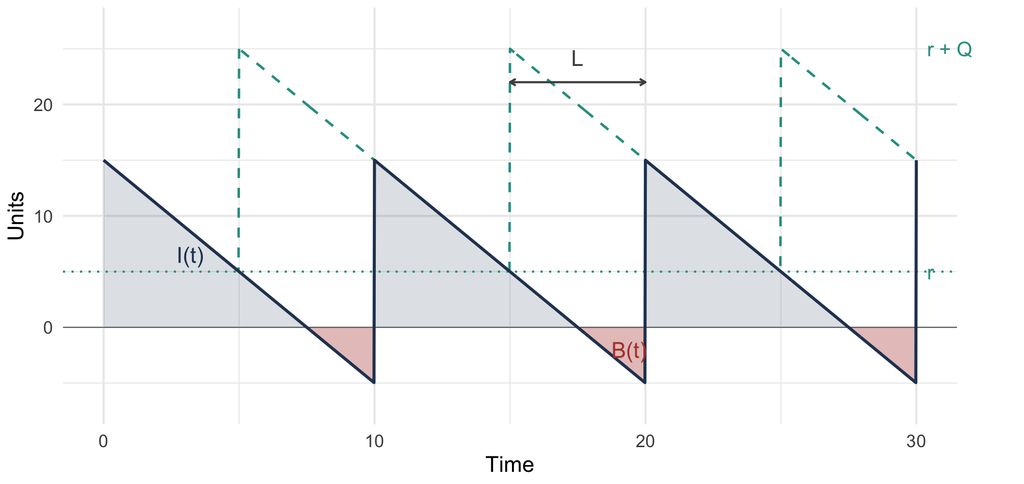

## Walking the Trace

Both lines start high, just after a receipt, and decline at the demand rate.

Early in each cycle they lie **on top of each other**. No order is outstanding, so $\mathit{IO}(t) = 0$ and position equals net inventory.

The dashed line reaches $r$, an order is placed, and the position **jumps by $Q$** while net inventory does not move at all, because nothing has arrived.

The two run apart for exactly one lead time $L$.

Net inventory continues down, crosses zero, and the shaded region below the axis is backorders accumulating while the order is in transit.

## The Point of the Picture

The position sawtooths safely between $r$ and $r + Q$ and **never runs short**.

Net inventory does.

The reorder point $r$ does not determine when the system runs out.

What determines that is $r$ measured against **demand over the lead time**.

## Averages Are Time Averages

Each state variable is **time-persistent**: it holds a value over an interval rather than being observed at isolated instants.

$$\bar{I} = \frac{1}{T}\int_{0}^{T} I(t)\,dt,
\qquad
\bar{B} = \frac{1}{T}\int_{0}^{T} B(t)\,dt$$

These integrals are where the two halves of the course meet.

In a **deterministic** model $I(t)$ is a known piecewise-linear function and the integral is the area of a triangle.

In a **stochastic** model the same integral is an expectation.

The quantity being computed does not change. Only the method does.

## Little’s Law

For any system in steady state, the average number of items **inside** equals the arrival rate times the average time each spends there.

$$\bar{N} = \lambda \bar{T}$$

Choosing what counts as “inside” is what generates the results.

We apply it three times, to three different flows of units.

## Inside Number One: The Pipeline

Units enter when **ordered** and leave when **received**, spending the lead time inside.

$$\overline{\mathit{IO}} = \lambda \overline{L}$$

Notice that **no ordering policy appears**. So no ordering policy can reduce it.

Pipeline stock is often mistaken for a target of improvement. It is a consequence of how fast you sell and how long your supplier takes, and it responds only to changing one of those.

## Inside Number Two: The Backorder Queue

Units enter when **demanded and unfilled**, and leave when **supplied**, spending the customer’s wait inside.

$$\bar{B} = \lambda \overline{W}$$

Average backorders and average customer waiting are **two views of one quantity**.

This matters practically. An organization that cannot price a backorder can usually state a **tolerable wait**, and that statement is enough to pin down what the backorder cost would have multiplied.

## Inside Number Three: The Shelf

Units enter when a replenishment is **received** and leave when they are **demanded**.

$$\bar{I} = \lambda \overline{T}_{s}
\qquad\Longleftrightarrow\qquad
\overline{T}_{s} = \frac{\bar{I}}{\lambda}$$

Its reciprocal is a quantity every operations manager already knows:

$$\mathit{TO} = \frac{\lambda}{\bar{I}} = \frac{1}{\overline{T}_{s}}$$

**Inventory turnover is nothing more than the reciprocal of the average time a unit sits on a shelf.**

## Turnover, Translated

> “We turn this item four times a year.”

> “A unit sits here three months on average.”

These are the **same statement**.

Turnover is reported by almost every organization and understood by people who would not sit through a derivation.

It also supplies a sanity check available **before any modeling begins**: an item whose computed $\bar{I}$ implies a turnover far from what the business reports has been mis-specified somewhere.

## What We Did Today

**There is no single inventory model**, and classification is how you find the right machinery. Nine questions, and the second one splits the course.

**Three counts and two composites** describe any inventory system, and on hand and backordered are never both positive.

**Policies read the position, not the shelf**, because the position counts what is already coming.

**Little’s law three times** gives pipeline stock, the backorder-wait identity, and turnover.

## For Next Time

**Read before next session:** *Cost Parameters*, *Estimating Cost Parameters from Standard Data*, and *Performance Measures*.

Next session:

- The six cost terms, and the units check that catches most first models
- The **marginality test**: one question that decides what belongs in a parameter
- Building a carrying charge and an order cost from an actual ledger
- Why three service measures on one demand history give 40%, 67%, and 60%

Everything next session attaches a rate of money to a quantity we defined today. No new state variables are coming.

⌂ Index